# Job analysis

Steven Bontius

7-3-2022

# Analysis of indeed vacancies

This report will analyse the job vacancies posted on indeed for the position of data analist scraped from indeed on the 5th of March 2022.

## Job title

The searching algorithm of indeed does not only return vacancies with the job title of “data analist” but also returns other job titles. Looking at the data reveals the following.

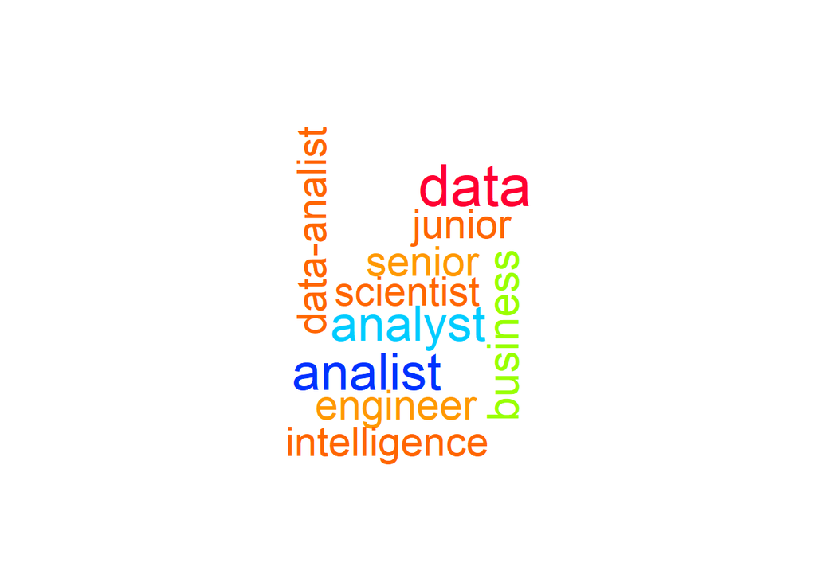

```r
job_titles <- Corpus(VectorSource(vacancies$job_title))
job_titles_clean <- tm_map(job_titles, content_transformer(tolower))
job_titles_clean <- tm_map(job_titles_clean, stripWhitespace)
wordcloud(job_titles_clean, scale = c(3, 2), min.freq = 15, colors = rainbow(30))
```

Besides the obvious data analist and the English equivalent the following interesting words can be found:

- junior & senior
- business
- intelligence
- scientist

Looking at the data set the following other job titles can be distilled

- Business analist
- Business intelligence analist
- Data scientist

Although a business analist is substantially different from a data analist some of the vacancies do not describe a true business analist function but are a data analist function in disguise.

A business intelligence analist is more geared to KPI’s and dashboards and is a job title that should be explored in the future.

A data scientist is more geared to machine learing, but similar to the business analist the job title is not always accurate.

# Findings

- Job titles are not always indicative of the actual job activities
- Investigate the job title of business intelligence analist